# Assignment 3

# Dataset Description: U.S. Bilateral Trade in Poultry Products

This dataset contains bilateral international trade data for the United States as the reporter country, focusing on the commodity classified under “**meat and edible offal**” of poultry, traded in fresh, chilled, or frozen form.

The dataset includes poultry products, covering common cuts and parts such as breasts, thighs, wings, livers, hearts, and gizzards. It excludes live poultry and processed poultry products.

Trade flows are reported with all countries as partners, meaning the data capture U.S. poultry trade with every trading partner (countries) worldwide. The dataset includes:

- Imports: Poultry products entering the United States from foreign suppliers (e.g., frozen chicken from Brazil or Canada).
- Exports: Poultry products shipped from the United States to international markets (e.g., U.S. poultry exports to Mexico or Asian countries).

# Data Source:

The dataset is obtained from the UN Comtrade database, an open-access repository of official international trade statistics compiled from customs data reported by over 150 countries. Key variables include trade values (USD) and quantities (kilograms), reflecting officially reported bilateral trade flows between the United States and its trading partners.

# General directions

1. For each question, you are encouraged to create a chunk below it, and fully develop the code that creates your answer.
2. You are encouraged to use wrangling functions from the packages `dplyr` and `tidyr`, and plotting functions from the package `ggplot2`.
3. You are encouraged to the the pipe operator (`%>%` or `|>`) to pipe wrangling steps together.
4. For each question, after showing your code and output (be it numerical or graphical), you also need to provide a written sentence of your answer. Just showing code output is not sufficient for full points.
5. As part of the initial wrangling, you are expected to:
- Transform the `qty` column from kg to Mg
- Select only columns that are useful to answer the questions.
6. Check out the following cheatsheets to give you some ideas on wrangling and plotting:
- **ggplot2**: https://posit.co/wp-content/uploads/2022/10/data-visualization-1.pdf
- **dplyr**: https://rstudio.github.io/cheatsheets/data-transformation.pdf

## Dataset

```r
library(dplyr)
library(tidyr)
library(ggplot2)
PoultryData <- read.csv("../Data/03_assignment_data.csv")
# glimpse(PoultryData)
# colnames(PoultryData)
# identical(PoultryData$qty, PoultryData$net_wgt)

PoultryDataClean <- PoultryData %>%
  mutate(
    qty_mg = qty/1000
    ) %>%
  dplyr::select(
    ref_year,
    flow_desc,
    partner_desc,
    primary_value,
    qty_mg
    ) %>%
  arrange(
    flow_desc
    )

head(PoultryDataClean)
```

```
  ref_year flow_desc        partner_desc primary_value     qty_mg
1     2018    Export         Afghanistan      19773534  24903.909
2     2018    Export             Albania       8430470  10312.728
3     2018    Export              Angola     183671360 209389.412
4     2018    Export Antigua and Barbuda       5675517   4283.972
5     2018    Export          Azerbaijan        297109    544.500
6     2018    Export           Argentina         59264     77.369
```

# Assignemnt Questions:

## Imports:

#### 1. How many distinct countries were there (based on given data), from where US was importing the poultry products from 2018-2024?

```r
PoultryDataClean_Import <- filter(PoultryDataClean,
                              flow_desc == "Import",
                              ref_year >= 2018,
                              ref_year <= 2024
                                  )

PoultryDataClean_Import
```

```
   ref_year flow_desc partner_desc primary_value    qty_mg
1      2018    Import       Canada     117042640 31582.204
2      2018    Import        Chile     139757883 40202.179
3      2018    Import      Germany        206221    66.053
4      2018    Import       Israel       8305053  1693.018
5      2019    Import       Canada     107515496 25899.826
6      2019    Import        Chile     131188057 40759.904
7      2019    Import       Israel       4737344  1025.837
8      2020    Import       Canada     112060969 28479.509
9      2020    Import        Chile     159895782 48575.220
10     2020    Import        China        106106    15.008
11     2021    Import       Canada     121460429 26899.262
12     2021    Import        Chile     259098134 55468.699
13     2021    Import       Mexico       2487672   798.645
14     2022    Import       Canada     137086022 32633.190
15     2022    Import        Chile     428214676 89480.404
16     2022    Import       Mexico       1107585   339.659
17     2022    Import       Poland          4308     0.420
18     2023    Import       Canada     135330409 30844.366
19     2023    Import        Chile     192506652 50171.086
20     2023    Import       Mexico        248875   204.265
21     2024    Import       Canada     146943943 31792.552
22     2024    Import        Chile     222025539 55309.008
23     2024    Import       Mexico        267323   187.120
```

```r
PoultryDataClean_Import_CountryNum <- n_distinct(PoultryDataClean_Import$partner_desc)

PoultryDataClean_Import_CountryNum
```

```
[1] 7
```

Based on given data, from 2018-2024, US imported poultry products from seven distinct countries.

#### 2. What are the minimum, maximum trade values for imports? Mention the country, year and its respective value.

```r
Tradevalues_Import <- PoultryDataClean_Import %>%
  dplyr::select(
                partner_desc,
                ref_year,
                primary_value
                )

Tradevalues_Import
```

```
   partner_desc ref_year primary_value
1        Canada     2018     117042640
2         Chile     2018     139757883
3       Germany     2018        206221
4        Israel     2018       8305053
5        Canada     2019     107515496
6         Chile     2019     131188057
7        Israel     2019       4737344
8        Canada     2020     112060969
9         Chile     2020     159895782
10        China     2020        106106
11       Canada     2021     121460429
12        Chile     2021     259098134
13       Mexico     2021       2487672
14       Canada     2022     137086022
15        Chile     2022     428214676
16       Mexico     2022       1107585
17       Poland     2022          4308
18       Canada     2023     135330409
19        Chile     2023     192506652
20       Mexico     2023        248875
21       Canada     2024     146943943
22        Chile     2024     222025539
23       Mexico     2024        267323
```

```r
Tradevalues_Import_min <- arrange(
                                  Tradevalues_Import,
                                  primary_value
                                  ) %>%
  slice(1)

Tradevalues_Import_min
```

```
  partner_desc ref_year primary_value
1       Poland     2022          4308
```

```r
Tradevalues_Import_max <- arrange(
                                  Tradevalues_Import,
                                  desc(primary_value)
                                  ) %>%
  slice(1)

Tradevalues_Import_max
```

```
  partner_desc ref_year primary_value
1        Chile     2022     428214676
```

The minimum trade value for imports was $4,308 from Poland in 2022. The maximum trade value for imports was $428,214,676 from Chile in 2022.

#### 3. Identify the top 5 countries from which the USA imported the most (qty) in the years 2018 and 2024. List the countries and their corresponding import values.

```r
TopfiveCountry_Import_2018 <- PoultryDataClean_Import %>%
  filter(ref_year == 2018) %>%
  group_by(partner_desc) %>%
  summarise(
    qty = sum(qty_mg),
    tradevalue = sum(primary_value)) %>%
  arrange(desc(qty)) %>%
  slice(1:5)

TopfiveCountry_Import_2018
```

```
# A tibble: 4 × 3
  partner_desc     qty tradevalue
  <chr>          <dbl>      <int>
1 Chile        40202.   139757883
2 Canada       31582.   117042640
3 Israel        1693.     8305053
4 Germany         66.1     206221
```

```r
TopfiveCountry_Import_2024 <- PoultryDataClean_Import %>%
  filter(ref_year == 2024) %>%
  group_by(partner_desc) %>%
  summarise(
    qty = sum(qty_mg),
    tradevalue = sum(primary_value)) %>%
  arrange(desc(qty)) %>%
  slice(1:5)

TopfiveCountry_Import_2024
```

```
# A tibble: 3 × 3
  partner_desc    qty tradevalue
  <chr>         <dbl>      <int>
1 Chile        55309.  222025539
2 Canada       31793.  146943943
3 Mexico         187.     267323
```

The results are based on my understanding of this question. I understood “in the years 2018 and 2024” to mean that the top five country should be identified separately for 2018 and 2024, which is also more meaningful to compare. In addition, “import values” was interpreted as the primary trade value (primaryValue), rather than the values of physical quantity (qty).

Based on the interpretation above:

In 2018, the U.S. imported poultry products from only four countries. These were Chile ($139,757,883), Canada ($117,042,640), Israel ($8,305,053), and Germany ($206,221).

In 2024, the U.S. imported poultry products from only three countries. These were Chile ($222,025,539), Canada ($146,943,943), and Mexico ($267,323).

#### 4. Calculate the total import value for the USA from each country. Which country had the highest total export value **to** US, and what was that value?

```r
TotalImportValue_Country <- PoultryDataClean_Import %>%
  dplyr::select(partner_desc,
                primary_value
                ) %>%
  group_by(partner_desc) %>%
  summarise(Total_import_tradevalue = sum(primary_value)) %>%
  arrange(desc(Total_import_tradevalue))

TotalImportValue_Country
```

```
# A tibble: 7 × 2
  partner_desc Total_import_tradevalue
  <chr>                          <int>
1 Chile                     1532686723
2 Canada                     877439908
3 Israel                      13042397
4 Mexico                       4111455
5 Germany                       206221
6 China                         106106
7 Poland                          4308
```

The results are based on my understanding of this question. The “import value” was interpreted as the primary trade value (primaryValue). The question was asking years from 2018 to 2024.

Chile had the highest total export value ($1,532,686,723) to US.

#### 5. Calculate the total import value for the USA in each year from 2018 to 2025. Which year had the highest total import value, and what was that value?

```r
TotalImportValue_Yearly <- PoultryDataClean_Import %>%
  dplyr::select(ref_year,
                primary_value
                ) %>%
  group_by(ref_year) %>%
  summarise(Total_import_tradevalue = sum(primary_value)) %>%
  arrange(desc(Total_import_tradevalue))

TotalImportValue_Yearly
```

```
# A tibble: 7 × 2
  ref_year Total_import_tradevalue
     <int>                   <int>
1     2022               566412591
2     2021               383046235
3     2024               369236805
4     2023               328085936
5     2020               272062857
6     2018               265311797
7     2019               243440897
```

Based on the provided dataset, the available data cover the years 2018 to 2024 only.

The highest total import value ($566,412,591) occurred in 2022.

#### 6. Plot a line graph showing the total annual import value for the USA from 2018 to 2024. Describe any noticeable trends or patterns (e.g., increases, decreases, or fluctuations) in the graph. Create a publication ready plot.

```r
TotalImportValue_Yearly_1 <- mutate(TotalImportValue_Yearly,
                                    Total_import_tradevalue_million = Total_import_tradevalue/1000000)

TotalImportValue_Yearly_1
```

```
# A tibble: 7 × 3
  ref_year Total_import_tradevalue Total_import_tradevalue_million
     <int>                   <int>                           <dbl>
1     2022               566412591                            566.
2     2021               383046235                            383.
3     2024               369236805                            369.
4     2023               328085936                            328.
5     2020               272062857                            272.
6     2018               265311797                            265.
7     2019               243440897                            243.
```

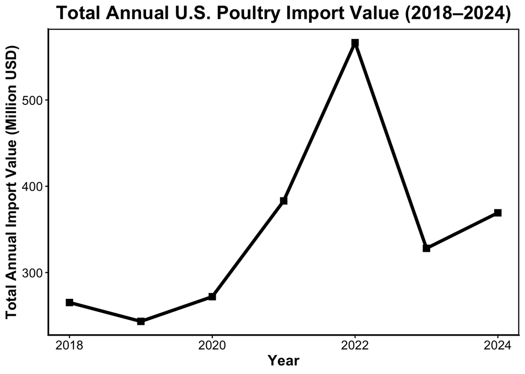

```r
ggplot(data = TotalImportValue_Yearly_1,
       aes(x = ref_year,
           y = Total_import_tradevalue_million)
       ) +
  geom_line(color = "black",
                 linewidth = 1.5) +
  geom_point(color = "black",
             size = 3,
             shape = 15) +
  labs(x = "Year",
       y = "Total Annual Import Value (Million USD)",
       title = "Total Annual U.S. Poultry Import Value (2018–2024)") +
  theme_classic() +
  theme(plot.title = element_text(hjust = 0.5, size = 18, face = "bold"),
        axis.title = element_text(size = 14, face = "bold"),
        axis.text = element_text(size = 12),
        panel.border = element_rect(color = "black", fill = NA, linewidth = 1)
        )
```

As shown in this figure, the total annual import value for the U.S. decreased from 2018 to 2019, and then increased steadily until 2022. After that, there was a sharp decrease in 2023, followed by a gradual increase in 2024.

## Exports:

#### 7. How many distinct countries were there (based on given data), to where US was exporting the poultry products?

```r
PoultryDataClean_Export <- filter(PoultryDataClean,
                              flow_desc == "Export",
                              ref_year >= 2018,
                              ref_year <= 2024
                                  )

head(PoultryDataClean_Export)
```

```
  ref_year flow_desc        partner_desc primary_value     qty_mg
1     2018    Export         Afghanistan      19773534  24903.909
2     2018    Export             Albania       8430470  10312.728
3     2018    Export              Angola     183671360 209389.412
4     2018    Export Antigua and Barbuda       5675517   4283.972
5     2018    Export          Azerbaijan        297109    544.500
6     2018    Export           Argentina         59264     77.369
```

```r
PoultryDataClean_Export_CountryNum <- n_distinct(PoultryDataClean_Export$partner_desc)

PoultryDataClean_Export_CountryNum
```

```
[1] 188
```

Based on given data, from 2018-2024, US exported poultry products to 188 distinct countries.

#### 8. What are the minimum, maximum trade values for exports? Mention the country, year and its respective value.

```r
Tradevalues_Export <- PoultryDataClean_Export %>%
  dplyr::select(
                partner_desc,
                ref_year,
                primary_value
                )

head(Tradevalues_Export)
```

```
         partner_desc ref_year primary_value
1         Afghanistan     2018      19773534
2             Albania     2018       8430470
3              Angola     2018     183671360
4 Antigua and Barbuda     2018       5675517
5          Azerbaijan     2018        297109
6           Argentina     2018         59264
```

```r
Tradevalues_Export_min <- arrange(
                                  Tradevalues_Export,
                                  primary_value
                                  ) %>%
  slice(1)

Tradevalues_Export_min
```

```
  partner_desc ref_year primary_value
1      Czechia     2018          2900
```

```r
Tradevalues_Export_max <- arrange(
                                  Tradevalues_Export,
                                  desc(primary_value)
                                  ) %>%
  slice(1)

Tradevalues_Export_max
```

```
  partner_desc ref_year primary_value
1       Mexico     2024    1172550687
```

The minimum trade value for exports was $2,900 to Czechia in 2018. The maximum trade value for exports was $1,172,550,687 to Mexico in 2024.

#### 9. Identify the top 5 countries to which the USA exported the most (qty) in the years 2018 and 2024. List the countries and their corresponding export values.

```r
TopfiveCountry_Export_2018 <- PoultryDataClean_Export %>%
  filter(ref_year == 2018) %>%
  group_by(partner_desc) %>%
  summarise(
    qty = sum(qty_mg),
    tradevalue = sum(primary_value)) %>%
  arrange(desc(qty)) %>%
  slice(1:5)

TopfiveCountry_Export_2018
```

```
# A tibble: 5 × 3
  partner_desc             qty tradevalue
  <chr>                  <dbl>      <int>
1 Mexico               792813.  763541266
2 China, Hong Kong SAR 291713.  412669749
3 Angola               209389.  183671360
4 Other Asia, nes      202493.  188024792
5 Cuba                 195235.  154537803
```

```r
TopfiveCountry_Export_2024 <- PoultryDataClean_Export %>%
  filter(ref_year == 2024) %>%
  group_by(partner_desc) %>%
  summarise(
    qty = sum(qty_mg),
    tradevalue = sum(primary_value)) %>%
  arrange(desc(qty)) %>%
  slice(1:5)

TopfiveCountry_Export_2024
```

```
# A tibble: 5 × 3
  partner_desc        qty tradevalue
  <chr>             <dbl>      <int>
1 Mexico          852904. 1172550687
2 Cuba            239643.  298231173
3 Other Asia, nes 210049.  261812562
4 Philippines     163084.  187724475
5 Canada          148189.  403487221
```

The results are based on my understanding of this question. I understood “in the years 2018 and 2024” to mean that the top five country should be identified separately for 2018 and 2024, which is also more meaningful to compare. In addition, “import values” was interpreted as the primary trade value (primaryValue), rather than the values of physical quantity (qty).

Based on the interpretation above:

In 2018, the top five countries to which the USA exported the most are Mexico ($763,541,266), China, Hong Kong SAR ($412,669,749), Angola ($183,671,360), Other Asia, nes ($188,024,792), and Cuba ($154,537,803).

In 2024, the top five countries to which the USA exported the most are Mexico ($1,172,550,687), Cuba ($298,231,173), Other Asia, nes ($261,812,562), Philippines ($187,724,475), and Canada ($403,487,221).

#### 10. Calculate the total export value for the USA from each country. Which country had the highest total import value **from** US, and what was that value?

```r
TotalExportValue_Country <- PoultryDataClean_Export %>%
  dplyr::select(partner_desc,
                primary_value
                ) %>%
  group_by(partner_desc) %>%
  summarise(Total_export_tradevalue = sum(primary_value)) %>%
  arrange(desc(Total_export_tradevalue))

TotalExportValue_Country
```

```
# A tibble: 188 × 2
   partner_desc         Total_export_tradevalue
   <chr>                                  <dbl>
 1 Mexico                            6823047519
 2 China                             3813940305
 3 Canada                            2227869347
 4 Other Asia, nes                   1674974582
 5 Cuba                              1635093053
 6 China, Hong Kong SAR              1143876295
 7 Angola                            1028925256
 8 Guatemala                         1004824791
 9 Philippines                        978700870
10 Viet Nam                           869091874
# ℹ 178 more rows
```

The results are based on my understanding of this question. The “export value” was interpreted as the primary trade value (primaryValue). The question was asking years from 2018 to 2024.

Mexico had the highest total import value ($6,823,047,519) from US.

#### 11. Calculate the total export value for the USA in each year from 2018 to 2025. Which year had the highest total export value, and what was that value?

```r
TotalExportValue_Yearly <- PoultryDataClean_Export %>%
  dplyr::select(ref_year,
                primary_value
                ) %>%
  group_by(ref_year) %>%
  summarise(Total_export_tradevalue = sum(primary_value)) %>%
  arrange(desc(Total_export_tradevalue))

TotalExportValue_Yearly
```

```
# A tibble: 7 × 2
  ref_year Total_export_tradevalue
     <int>                   <dbl>
1     2022              5401343250
2     2023              4886389111
3     2021              4772894502
4     2024              4766297796
5     2020              3837181558
6     2019              3749261464
7     2018              3628826731
```

Based on the provided dataset, the available data cover the years 2018 to 2024 only.

The highest total export value ($5,401,343,250) occurred in 2022.

#### 12. Plot a line graph showing the total annual export value for the USA from 2018 to 2024. Describe any noticeable trends or patterns (e.g., increases, decreases, or fluctuations) in the graph. Create a publication ready plot.

```r
TotalExportValue_Yearly_1 <- mutate(TotalExportValue_Yearly,
                                    Total_export_tradevalue_million = Total_export_tradevalue/1000000)

TotalExportValue_Yearly_1
```

```
# A tibble: 7 × 3
  ref_year Total_export_tradevalue Total_export_tradevalue_million
     <int>                   <dbl>                           <dbl>
1     2022              5401343250                           5401.
2     2023              4886389111                           4886.
3     2021              4772894502                           4773.
4     2024              4766297796                           4766.
5     2020              3837181558                           3837.
6     2019              3749261464                           3749.
7     2018              3628826731                           3629.
```

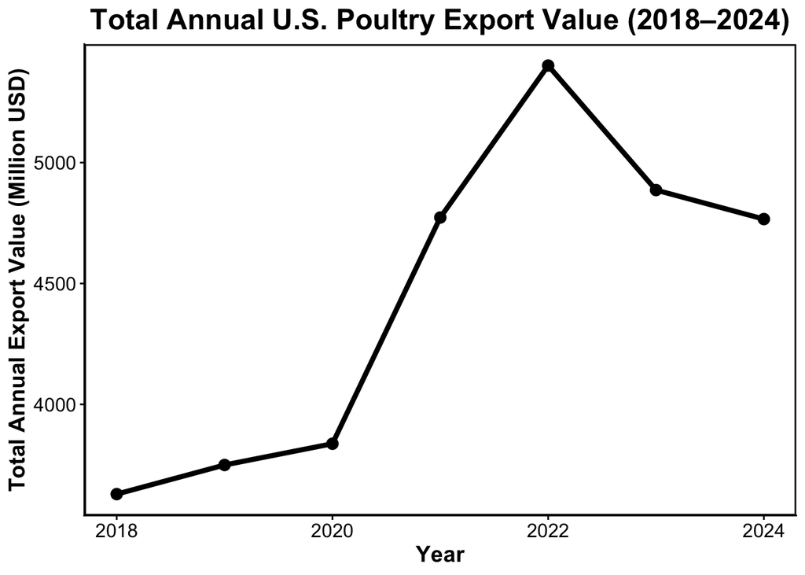

```r
ggplot(data = TotalExportValue_Yearly_1,
       aes(x = ref_year,
           y = Total_export_tradevalue_million)
       ) +
  geom_line(color = "black",
                 linewidth = 1.5) +
  geom_point(color = "black",
             size = 3) +
  labs(x = "Year",
       y = "Total Annual Export Value (Million USD)",
       title = "Total Annual U.S. Poultry Export Value (2018–2024)") +
  theme_classic() +
  theme(plot.title = element_text(hjust = 0.5, size = 18, face = "bold"),
        axis.title = element_text(size = 14, face = "bold"),
        axis.text = element_text(size = 12),
        panel.border = element_rect(color = "black", fill = NA, linewidth = 1)
        )
```

As shown in this figure, the total annual export value for the U.S. increased gradually from 2018 to 2020, followed by a sharp increase until 2022. After 2022, the export value decreased sharply in 2023 and then declined slightly in 2024.

## Imports - Exports Comparision:

#### 13. Does the U.S. behave more as a net importer or net exporter for this commodity? Explore it:

- Based on total value US imports and exports.

```r
TotalValue <- PoultryDataClean %>%
  group_by(flow_desc) %>%
  summarise(sum(primary_value))

TotalValue
```

```
# A tibble: 2 × 2
  flow_desc `sum(primary_value)`
  <chr>                    <dbl>
1 Export             31042194412
2 Import              2427597118
```

The total values of U.S. exports and imports from 2018 to 2024 were $31042194412 and $2427597118, respectively. Based on these data, the United States was a net exporter of poultry products during this period.

- Based on number of countries US imports and exports

```r
TotalCountryNumber <- PoultryDataClean %>%
  group_by(flow_desc) %>%
  summarise(countrynumber = n_distinct(partner_desc))

TotalCountryNumber
```

```
# A tibble: 2 × 2
  flow_desc countrynumber
  <chr>             <int>
1 Export              188
2 Import                7
```

The number of countries of U.S. exports and imports from 2018 to 2024 were 188 and 7, respectively. Based on these data, the United States was a net exporter of poultry products during this period.

- Based on each year’s import export value.

```r
Annualvalues <- PoultryDataClean %>%
  group_by(flow_desc,
            ref_year) %>%
  summarise(primary_value_annually = sum(primary_value)) %>%
  pivot_wider(names_from = flow_desc,
              values_from = primary_value_annually
              )
Annualvalues
```

```
# A tibble: 7 × 3
  ref_year     Export    Import
     <int>      <dbl>     <dbl>
1     2018 3628826731 265311797
2     2019 3749261464 243440897
3     2020 3837181558 272062857
4     2021 4772894502 383046235
5     2022 5401343250 566412591
6     2023 4886389111 328085936
7     2024 4766297796 369236805
```

From 2018 to 2024, the U.S. export values were consistently greater than import values, indicating that the U.S. was a net exporter of poultry products during this period.

#### 14. Are the main import partners also major export destinations? Explore it based on the total import export value by countries.

```r
Totalvalues_Country <- PoultryDataClean %>%
  group_by(flow_desc,
           partner_desc) %>%
  summarise(primary_value_country = sum(primary_value)) %>%
  pivot_wider(names_from = flow_desc,
              values_from = primary_value_country) %>%
  arrange(desc(Import))
Totalvalues_Country
```

```
# A tibble: 188 × 3
   partner_desc     Export     Import
   <chr>             <dbl>      <dbl>
 1 Chile         372480927 1532686723
 2 Canada       2227869347  877439908
 3 Israel          1405217   13042397
 4 Mexico       6823047519    4111455
 5 Germany         4510221     206221
 6 China        3813940305     106106
 7 Poland           134120       4308
 8 Afghanistan    55030863         NA
 9 Albania        73341752         NA
10 Algeria           34840         NA
# ℹ 178 more rows
```

#### 15. Can you calculate if US is in trade surplus or trade deficit for each year from 2018-2024?

$$\text{Trade surplus or deficit} = \text{Imports} - \text{Exports}$$

```r
TradeSituation <- PoultryDataClean %>%
  group_by(flow_desc,
            ref_year) %>%
  summarise(primary_value_annually = sum(primary_value)) %>%
  pivot_wider(names_from = flow_desc,
              values_from = primary_value_annually
              ) %>%
  mutate(Tradesituation = Import - Export)
TradeSituation
```

```
# A tibble: 7 × 4
  ref_year     Export    Import Tradesituation
     <int>      <dbl>     <dbl>          <dbl>
1     2018 3628826731 265311797    -3363514934
2     2019 3749261464 243440897    -3505820567
3     2020 3837181558 272062857    -3565118701
4     2021 4772894502 383046235    -4389848267
5     2022 5401343250 566412591    -4834930659
6     2023 4886389111 328085936    -4558303175
7     2024 4766297796 369236805    -4397060991
```

Based on the calculation (Imports − Exports), all values are negative from 2018 to 2024, indicating that the U.S. experienced a trade surplus in poultry products in every year during this period.

# Submitting your work

Once you have developed all the code and answers, make sure to Render this quarto file.

**Notes on rendering**:

- Make sure to render your work and inspect how the final html look like.
- If it does not look professional for whatever reason, then fix the issue, re-render it, recheck.
- Only send me your work once your html file looks professional.
- Some potential issues you may encounter and how to fix them:
  - Some times your code may be creating a table output that is waaay too long and cumbersome to scroll through when rendered. If this is the case, make it more professional looking by using the `head()` function to only print the first handful of rows (instead of thousands of rows).
  - **DO NOT** delete the file’s heading levels (# and ##). They set up the proper heading 1 and 2 levels, and I use them to guide my grading.
  - There’s a total of **15 questions**. If you mess around with the heading levels and you get a different number of questions on the rendered version, fix it.
  - If a given chunk is also outputting warnings or messages, inhibit this behavior by changing the chunk options `message` and `warning` to `FALSE` (I’ll demo this in a moment).
  - If, after rendered, 2 lines of text are connected and you wish to “break line” between them, add 2 extra spaces after the first one (I’lld demo this in a moment).

After rendering, an .html file will be created on your `code` folder.

Rename this file to `03_assignment_LASTNAME.html`.

For ex., `03_assignment_Bastos.html`.

Submit the html file on eLC by Monday Feb 2nd 11:59 pm, **one week** from today.